# 問題２：線形回帰モデル

190名の乳幼児の性別（1 = 男，2 = 女），年齢 (月, months)，体重（kg）のデータを収集した．このデータを用いて，以下のことが知りたい：

- 子供の年齢が一ヶ月の上がると，体重はどれぐらい増えているか？
- 男の子は女の子と比べて，平均的に体重はどれぐらい多い/少ないか？

## データのインポート

### ステップ １

[figure not shown]

### ステップ２

[figure not shown]

### ステップ３

[figure not shown]

### ステップ４

[figure not shown]

### ステップ５

[figure not shown]

## 体重と年齢の散布図，体重の男女別箱ひげ図

[figure not shown]

上記左のグラフを描くため，以下のコードをRスクリプトに入力して，実行をクリックしてください．

[figure not shown]

```r
plot(Dataset$age,Dataset$wt,
     xlab = "年齢 (months)", ylab = "体重 (kg)",
     main = "体重と年齢の散布図",
     ylim = c(3, 20), pch=c(2))
```

男女別に体重の箱ひげ図を描くため，以下のコードをRスクリプトに入力して，実行をクリックしてください．

[figure not shown]

```r
boxplot(Dataset$wt ~ Dataset$sex, ylim = c(0, 18),
        main = "体重と年齢", xlab = "性別", ylab = "体重 (kg)",
        col = "green", names = c("男性", "女性"))
```

## 年齢，体重それぞれの平均値，分散を求めよ；また，年齢と体重の共分散を算出せよ．なお，EZRで計量データの平均値を計算するには，コマンド `mean(変数名)` を使う；共分散を計算したい時には，コマンド `cov(変数1, 変数2)` を利用する．

以下のコードをRスクリプトに入力して,実行をクリックしてください．

```r
# 年齢の平均値
mean(Dataset$age)
```

```
## [1] 16.97895
```

```r
# 年齢の分散
var(Dataset$age)
```

```
## [1] 69.5022
```

```r
# 体重の平均値
mean(Dataset$wt)
```

```
## [1] 9.644737
```

```r
# 体重の分散
var(Dataset$wt)
```

```
## [1] 3.513068
```

```r
# 体重と年齢の共分散 covariance
cov(Dataset$wt, Dataset$age)
```

```
## [1] 11.49089
```

## 年齢を説明変数，体重を目的変数とする場合，年齢の傾き(回帰係数)，と切片を求めよ．なお，分散と共分散の定義は以下とする，$\bar{X}$ は $X$ の平均値を示す：

- 分散 variance:

$$\begin{aligned}
\mathbf{Var}(X) & = \frac{(X_1-\bar{X})^2+(X_2-\bar{X})^2+\cdots+(X_n-\bar{X})^2}{n - 1} \\
& = \frac{\sum_{i=1}^n(X_i-\bar{X})^2}{n -1}
\end{aligned}$$

- 共分散 covariance:

$$\begin{aligned}
\mathbf{Cov}(X, Y) & = \frac{(X_1 - \bar{X})(Y_1-\bar{Y}) + (X_2 - \bar{X})(Y_2-\bar{Y}) + \cdots + (X_n - \bar{X})(Y_n-\bar{Y})}{n - 1} \\
& = \frac{\sum_{i = 1}^n(X_i - \bar{X})(Y_i-\bar{Y})}{n - 1}
\end{aligned}$$

以下のコードをRスクリプトに入力して,実行をクリックしてください．（結果を下の余白に記入すること）

```r
# 傾き (slope)
beta <- cov(Dataset$wt, Dataset$age) / var(Dataset$age)
beta
```

```
## [1] 0.1653314
```

```r
# 切片 (intercept)
alpha <- mean(Dataset$wt) - mean(Dataset$age)*beta
alpha
```

```
## [1] 6.837584
```

[figure not shown]

## 実際にEZRで線形モデルを作ってみよう：

### ステップ１

[figure not shown]

### ステップ２

[figure not shown]

### ステップ３

[figure not shown]

推定された回帰係数が自分の計算結果と一致するかを確認してください．

## 今まで計算した傾きと切片の数字を用いて，年齢と体重の関係を線形と考える場合の計算式を記入せよ．傾きと切片の計算結果の意味をそれぞれ記述せよ．

### 答え

$$Y = 6.838 + 0.165 X$$

- $Y:$ 体重 (kg)；
- $X:$ 年齢 (months)；
- $0.165:$ 子供の年齢が1ヶ月上がると，体重が平均的 0.165 kg (165 g) 高くなる；
- $6.838:$ 子供の年齢が0ヶ月の時に，体重の平均値は 6.838 kg．

## 性別を説明変数に入れたモデルを作る

### 性別変数を因子 (factor) に変換する

#### ステップ１

[figure not shown]

#### ステップ２

[figure not shown]

#### ステップ３

[figure not shown]

#### ステップ４–水準名に男性，女性を入力する

[figure not shown]

### 重回帰線形モデルを作る

#### ステップ１

[figure not shown]

#### ステップ２—複数の説明変数を選択する時に control キーを押しながらマウスで変数名をクリックする

[figure not shown]

### 重回帰線形モデルの結果を確認する

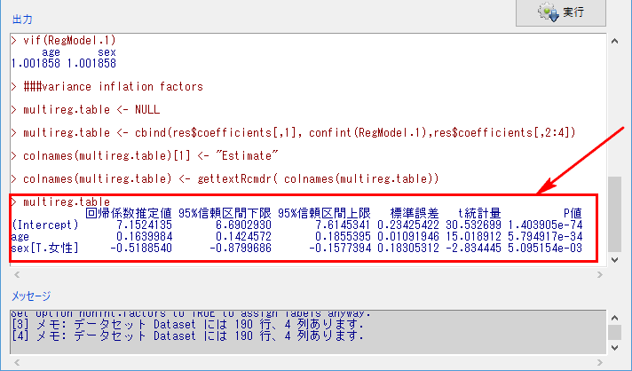

## 重回帰線形モデルの計算結果を用いて，体重の平均値を年齢と性別の線形モデルで表示せよ．各回帰係数の意味を説明せよ．

## 答え

$$Y = 7.152 + 0.164 X_1 - 0.519X_2$$

- $Y:$ 体重(kg)；
- $X_1:$ 年齢 (months)；
- $X_2 = 1:$ 女性；
- $X_2 = 0:$ 男性；
- $7.152:$ 男の子が年齢 0 ヶ月の時の平均体重；
- $0.164:$ 同じ性別の子供の年齢が1ヶ月上がることによって，体重が平均的に 0.164 kg増える；
- $-0.519:$ 子供年齢が同じ時に，女の子は男の子と比べ，体重が平均的に 0.519 kg低い．

## 上記の重回帰線形モデルを用いて，年齢が34ヶ月の女の子の体重の予測値を計算せよ．

## 答え

- $X_1 = 34$；
- $X_2 = 1$;

$$\begin{aligned}
Y & = 7.152 + 0.164 \times 34 -0.519\times 1 \\
& = 12.209\; \mathbf{(kg)}
\end{aligned}$$

## 男女別の年齢と体重の散布図を描く

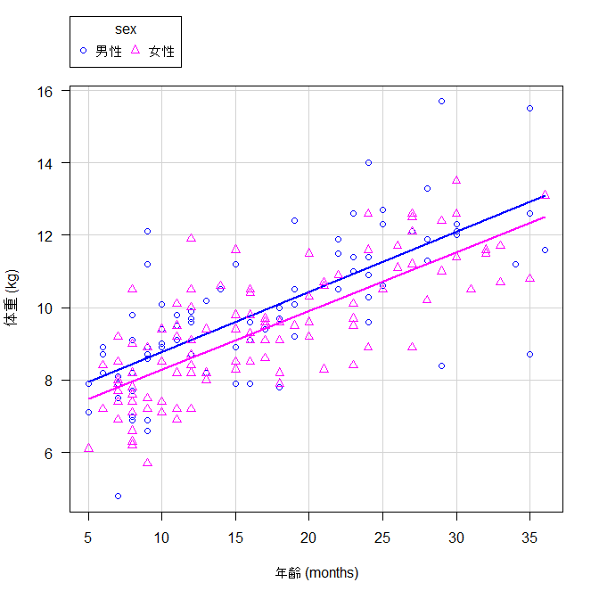

### ステップ１

[figure not shown]